# Exercise - Answer Key

## Lab 1

Load the dataset “mpg” and work through the exercises below. Note, “mpg” is included in the tidyverse package, so you will need to load the package first.

1. Calculate the **mean**, **range**, **minimum**, and **maximum** of the variable “hwy” across all models. Then, combine these statistics into one vector. (Tip: look up the RDocumentation for the functions `mean`, `range`, `min`, and `max`).

```r
library(tidyverse)
data(mpg)

mean_hwy <- mean(mpg$hwy)
range_hwy <- range(mpg$hwy)
min_hwy <- min(mpg$hwy)
max_hwy <- max(mpg$hwy)
sum_stats <- c(mean_hwy, range_hwy, min_hwy, max_hwy)
sum_stats
```

```
[1] 23.44017 12.00000 44.00000 12.00000 44.00000
```

2. Since “hwy” is measured in miles per gallon, create a new variable in mpg that expresses “hwy” in litres per 100 km.

```r
temp <- 235.215 / mpg$hwy
mpg$hwy_Lp100km_1 <- temp

# Or, in one step
mpg$hwy_Lp100km_2 <- 235.215 / mpg$hwy

unique(mpg$hwy_Lp100km_1 == mpg$hwy_Lp100km_2) # sanity check
```

```
[1] TRUE
```

3. Identify the models of cars that are most fuel-efficient. Which classes of cars are least fuel-efficient?

```r
mpg$model[mpg$hwy == max(mpg$hwy)]
```

```
[1] "jetta"      "new beetle"
```

```r
mpg$class[mpg$hwy_Lp100km_1 == max(mpg$hwy_Lp100km_1)]
```

```
[1] "pickup" "suv"    "pickup" "pickup" "suv"
```

```r
unique(mpg$class[mpg$hwy_Lp100km_1 == max(mpg$hwy_Lp100km_1)]) # using unique function to remove duplicates
```

```
[1] "pickup" "suv"
```

4. Compute the quantiles of “hwy”. Can you also calculate the tertiles instead? (Tip: look up for the RDocumentation for the function `quantile`).

```r
quantile(mpg$hwy)
```

```
  0%  25%  50%  75% 100%
  12   18   24   27   44
```

```r
quantile(mpg$hwy, probs = seq(0, 1, 0.333))
```

```
    0%  33.3%  66.6%  99.9%
12.000 19.589 26.000 44.000
```

```r
quantile(mpg$hwy, c(0, 0.333, 0.666, 1)) # you can achieve the same using this
```

```
    0%  33.3%  66.6%   100%
12.000 19.589 26.000 44.000
```

5. Now, based on the tertiles you calculated, assign “least efficient”, “medium”, and “most efficient” labels to all models. Try using both base R indexing and the function `ifelse`.

```r
tertile <- quantile(mpg$hwy, c(0, 0.333, 0.666, 1))

mpg$efficient_class_1 <- NA # optional, this eliminates the warning message of "Unknown or uninitialised column"
mpg$efficient_class_1[mpg$hwy < tertile[2]] <- "least efficient"
mpg$efficient_class_1[mpg$hwy >= tertile[2] & mpg$hwy < tertile[3]] <- "medium"
mpg$efficient_class_1[mpg$hwy >= tertile[3]] <- "most efficient"

# OR
mpg$efficient_class_2 <- NA # given how ifelse functions are specified below, this step becomes necessary
mpg$efficient_class_2 <- ifelse(mpg$hwy < tertile[2], "least efficient", mpg$efficient_class_2)
mpg$efficient_class_2 <- ifelse(mpg$hwy >= tertile[2] & mpg$hwy < tertile[3], "medium", mpg$efficient_class_2)
mpg$efficient_class_2 <- ifelse(mpg$hwy >= tertile[3], "most efficient", mpg$efficient_class_2)

unique(mpg$efficient_class_1 == mpg$efficient_class_2) # sanity check
```

```
[1] TRUE
```

## Lab 2

### Data Manipulation using dplyr

#### Part A

Continue from the farm business dataset “farm” used in Lab 2, work through the exercises below.

1. Create a new variable called **size3** that meets the following criteria:
   1. size3 = “small” if size <= 200
   2. size3 = “medium” if 200 < size <= 600
   3. size3 = “big” if size > 600

   Finally, convert size3 to a factor variable that is ordinal from “small” to “big”.

```r
name <- c("Henry", "Larry", "Alex", "Gaby", "Amy", "Ruby")
sex <- c("male", "male", "male", "female", "female", "female")
age <- c(43, 60, 25, 50, 28, 58)
type <- c("crop", "livestock", "urban", "dairy", "crop", "livestock")
size <- c(550, 800, 10, 600, 1000, 700)
return <- c(40, 90, 50, 90, 90, 95)

farm <- data.frame(name, age, sex, type, size, return)

farm <- farm %>% mutate(size3 = ifelse(size <= 200, "small", NA)) %>%
                 mutate(size3 = ifelse(size > 200 & size <= 600, "medium", size3)) %>%
                 mutate(size3 = ifelse(size > 600, "big", size3)) %>%
                 mutate(size3 = factor(size3, levels = c("small", "medium", "big")))

farm
```

| name | age | sex | type | size | return | size3 |
| --- | --- | --- | --- | --- | --- | --- |
| Henry | 43 | male | crop | 550 | 40 | medium |
| Larry | 60 | male | livestock | 800 | 90 | big |
| Alex | 25 | male | urban | 10 | 50 | small |
| Gaby | 50 | female | dairy | 600 | 90 | medium |
| Amy | 28 | female | crop | 1000 | 90 | big |
| Ruby | 58 | female | livestock | 700 | 95 | big |

```r
farm$size3
```

```
[1] medium big    small  medium big    big
Levels: small medium big
```

2. Generate the following summary statistics, for each type of the farms:
   1. the sum of all returns, called **tot.return**
   2. the average returns, called **avg.return**

   Finally, rearrange the data based on the value of avg.return, in the descending order.

```r
farm.sum <- farm %>% group_by(type) %>%
                     summarize(tot.return = sum(return),
                               avg.return = mean(return))

farm.sum <- arrange(farm.sum, desc(avg.return))
farm.sum
```

| type | tot.return | avg.return |
| --- | --- | --- |
| livestock | 185 | 92.5 |
| dairy | 90 | 90.0 |
| crop | 130 | 65.0 |
| urban | 50 | 50.0 |

#### Part B

Import data “mpg” and work through the coding below.

1. Drop the variables **displ**, **drv** and **fl**, then exclude cars that were manufactured by **Hyundai** and **Pontiac** .

```r
data(mpg)     # you may need to library(tidyverse) first

mpg <- mpg %>% select(-displ, -drv, -fl) %>%
               filter(manufacturer != "hyundai" & manufacturer != "pontiac")

head(mpg)
```

| manufacturer | model | year | cyl | trans | cty | hwy | class |
| --- | --- | --- | --- | --- | --- | --- | --- |
| audi | a4 | 1999 | 4 | auto(l5) | 18 | 29 | compact |
| audi | a4 | 1999 | 4 | manual(m5) | 21 | 29 | compact |
| audi | a4 | 2008 | 4 | manual(m6) | 20 | 31 | compact |
| audi | a4 | 2008 | 4 | auto(av) | 21 | 30 | compact |
| audi | a4 | 1999 | 6 | auto(l5) | 16 | 26 | compact |
| audi | a4 | 1999 | 6 | manual(m5) | 18 | 26 | compact |

```r
unique(mpg$manufacturer)
```

```
 [1] "audi"       "chevrolet"  "dodge"      "ford"       "honda"
 [6] "jeep"       "land rover" "lincoln"    "mercury"    "nissan"
[11] "subaru"     "toyota"     "volkswagen"
```

2. Continue from your dataframe above and generate the summary statistics, for each manufacturer, model, and year:
   1. the average of “cty”, called **avg.cty**
   2. the average of “hwy”, called **avg.hwy**
   3. the total number of cars produced, called **tot.cars**

```r
mpg.sum <- mpg %>% group_by(manufacturer, model, year) %>%
                   summarize(avg.cty = mean(cty),
                             avg.hwy = mean(hwy),
                             tot.cars = n())

head(mpg.sum)
```

| manufacturer | model | year | avg.cty | avg.hwy | tot.cars |
| --- | --- | --- | --- | --- | --- |
| audi | a4 | 1999 | 18.25000 | 27.50000 | 4 |
| audi | a4 | 2008 | 19.66667 | 29.33333 | 3 |
| audi | a4 quattro | 1999 | 16.50000 | 25.25000 | 4 |
| audi | a4 quattro | 2008 | 17.75000 | 26.25000 | 4 |
| audi | a6 quattro | 1999 | 15.00000 | 24.00000 | 1 |
| audi | a6 quattro | 2008 | 16.50000 | 24.00000 | 2 |

### Data Visualization using ggplot

#### Part A

Import data “mpg” and work through the exercises below.

1. Create a scatterplot that shows all of the following:
   1. use “cty” on the x-axis and “hwy” on the y-axis
   2. assign different colors for “class” and different shapes for “year”.  
      (tip: since continuous variables cannot be mapped to `shape`, you will need to convert “year” to a factor using `factor()`)
   3. fit **only one trend line** for all points

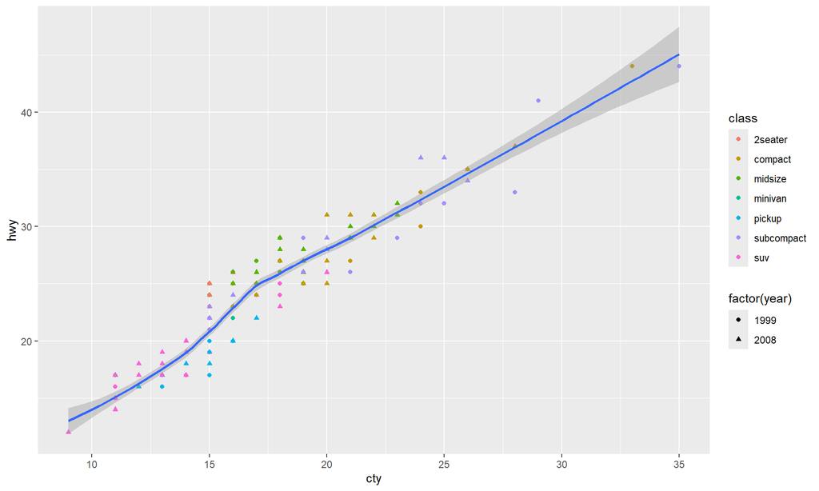

```r
data(mpg)     # library(tidyverse)

ggplot(mpg) +
  geom_point(aes(x= cty, y = hwy, color = class, shape = factor(year))) +
  geom_smooth(aes(x= cty, y = hwy))
```

2. Create a scatterplot that shows all of the following:
   1. use “displ” on the x-axis and “hwy” on the y-axis
   2. partition the graph into a grid by the combination of “drv” and “fl”, but only include “fl” that equals “p” or “r”
   3. fit a trend line in each graph within the grid

   (Tip: you can build from the example “p23” in Lab 2.)

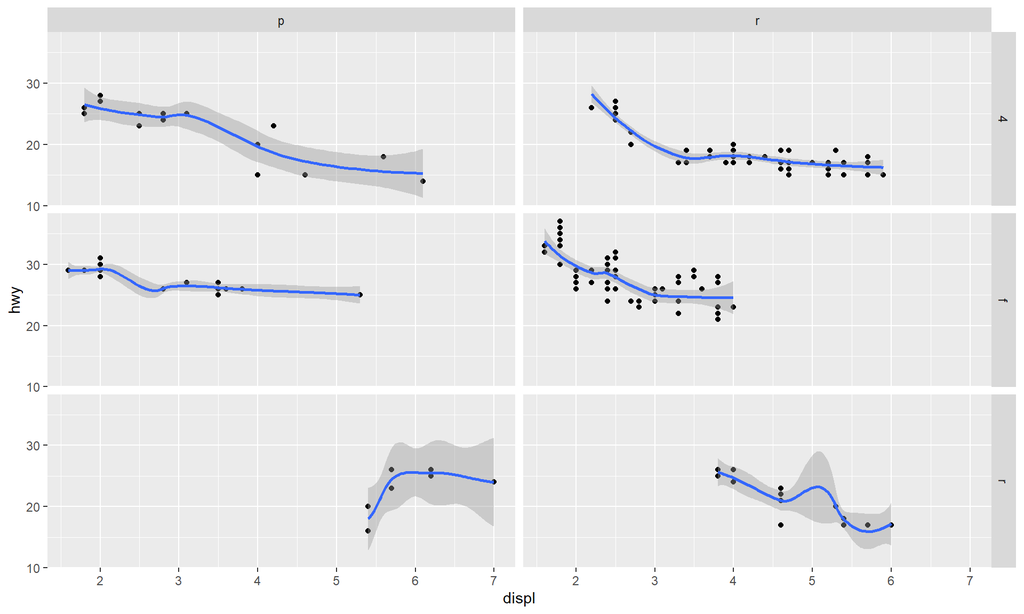

```r
mpg.mod <- mpg %>% filter(fl == "p" | fl == "r")

ggplot(mpg.mod, aes(x = displ, y = hwy)) +
  geom_point() +
  geom_smooth() +
  facet_grid(drv ~ fl)
```

3. Create a bar chart that shows the average “hwy” of all cars produced in 2008 by each of the following manufacturers:  
   **Audi**, **Hyundai**, **Nissan** and **Volkswagen**. Assign a different color to each manufacturer.

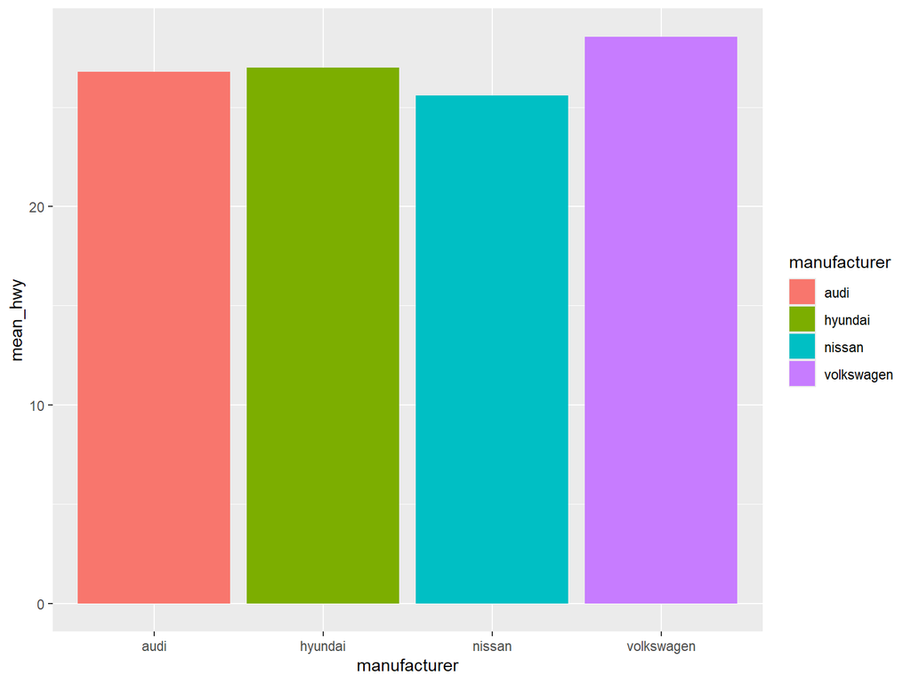

```r
mpg.sum <- mpg %>% filter(manufacturer == "audi" | manufacturer == "hyundai" |
                          manufacturer == "nissan" | manufacturer == "volkswagen") %>%
                   filter(year == 2008) %>%
                   group_by(manufacturer) %>%
                   summarize(mean_hwy = mean(hwy))

ggplot(mpg.sum, aes(x = manufacturer, y = mean_hwy, fill = manufacturer)) + geom_col()
```

#### Part B

Import the data “gapminder” and try to reproduce the graph below.

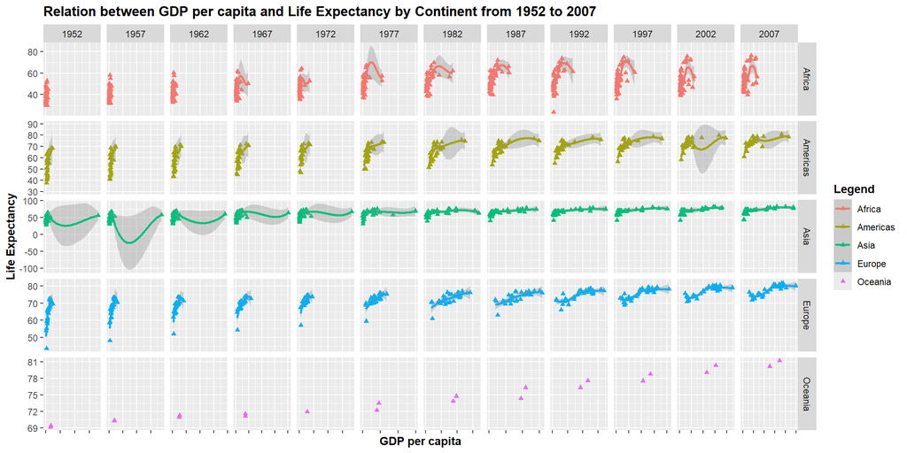

```r
library(gapminder)

ggplot(gapminder, aes(x = gdpPercap, y = lifeExp, color = continent)) +
  geom_point(shape = 17, size = 1.5) +
  geom_smooth() +
  facet_grid(continent ~ year, scales = "free") +

  labs(
    title = "Relation between GDP per capita and Life Expectancy by Continent from 1952 to 2007",
    x = "GDP per capita", y = "Life Expectancy", color = "Legend"
  ) +

  theme(
    axis.text.x = element_blank(),
    title = element_text(face = "bold")
  )
```